# Assignment3

Dea Karam

2026-03-11

# 1. Loading Required Packages

We begin by loading the Bioconductor and R packages required for this analysis.

```r
suppressPackageStartupMessages({
  library(AnnotationHub)
  library(Rsubread)      # read alignment
  library(rtracklayer)   # read/write genomic file formats
  library(Biostrings)    # handling sequences
  library(Rfastp)        # read QC/trimming
  library(epiwraps)
  library(MACSr)
  library(ensembldb)
  library(GenomicRanges)
})
ah <- AnnotationHub()
```

# 2. Downloading the raw sequencing reads

The raw sequencing reads used in this analysis are obtained from the ENCODE project.  
The FASTQ file containing CTCF ChIP-seq reads is downloaded directly and stored locally.

```r
options(timeout=3600)
dir.create("raw")
download.file("https://www.encodeproject.org/files/ENCFF127RRR/@@download/ENCFF127RRR.fastq.gz", "raw/ctcf.fastq.gz", mode="wb") # wb -> write binary. .gz is a compressed binary file.
```

# 3. Reads QC and trimming

Before alignment, sequencing reads are evaluated and processed using **Rfastp**, which performs quality control and optional trimming.  
The processed reads are written to a new directory so that downstream analyses use the cleaned dataset.

```r
dir.create("rfastp.trimmed", showWarnings = FALSE)

qc <- Rfastp::rfastp("raw/ctcf.fastq.gz", thread = 4, overrepresentationAnalysis = TRUE, outputFastq = "rfastp.trimmed/ctcf")
```

To evaluate the nucleotide composition across sequencing cycles, we visualize the base content before and after quality control.

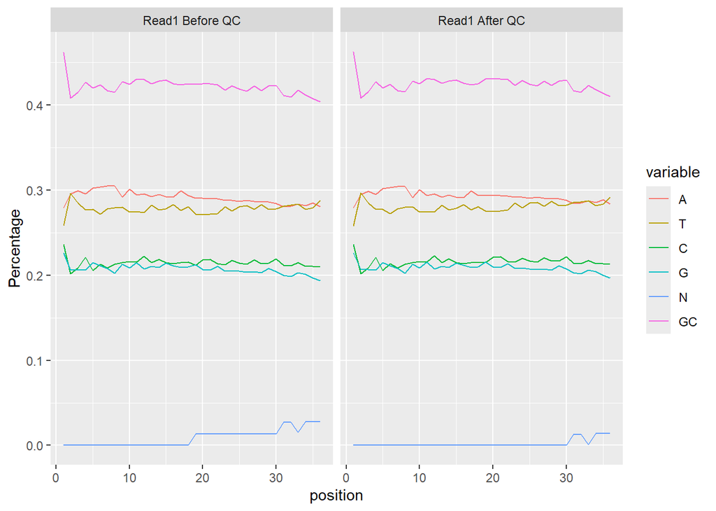

```r
Rfastp::curvePlot(qc, curve="content_curves")
```

The nucleotide composition remains relatively stable across read positions before and after QC, indicating no strong sequence bias in the reads.

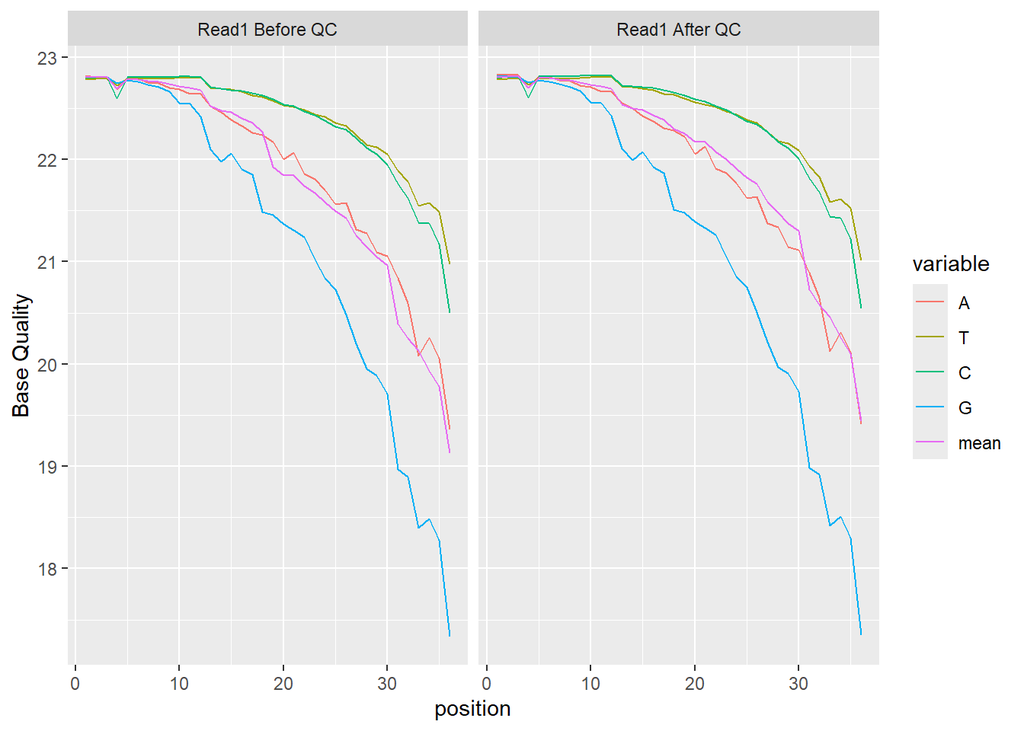

```r
Rfastp::curvePlot(qc, curve = "quality_curves")
```

As typical of sequencing data, base quality scores gradually decrease toward the end of reads.

QC processing does not substantially alter the overall quality profile.

# 4. Alignment

## 4.1 Downloading reference genome

To align the sequencing reads, we download the **Drosophila melanogaster reference genome (dm6 / BDGP6)** using AnnotationHub.

The genome sequence is exported locally in FASTA format for index construction and downstream alignment.

```r
genome <- ah[["AH49674"]]
```

```
## loading from cache
```

```r
dir.create("BDGP6_genome", showWarnings = FALSE)
export( import.2bit(genome), "BDGP6_genome/genome.fasta.gz", compress = TRUE)
```

## 4.2 Read alignment

The processed reads were aligned to the *Drosophila melanogaster* reference genome (BDGP6) using the **Rsubread** aligner.

The resulting alignments were saved in BAM format for downstream analysis.

```r
Rsubread::buildindex( basename = "BDGP6_genome/rsubread", reference = "BDGP6_genome/genome.fasta.gz"
)
```

```r
dir.create("aligned", showWarnings = FALSE)

align.stats <- Rsubread::align(
  index = "BDGP6_genome/rsubread",
  type = "dna",
  readfile1 = "rfastp.trimmed/ctcf_R1.fastq.gz",
  output_file = "aligned/ctcf.bam",
  nthreads = 6,
  sortReadsByCoordinates = TRUE
)
```

[output not shown]

[output cut: 33 more lines]

```
##
## //================================   Summary =================================\\
## ||                                                                            ||
## ||                 Total reads : 3816990                                      ||
## ||                      Mapped : 3504769 (91.8%)                              ||
## ||             Uniquely mapped : 3048315                                      ||
## ||               Multi-mapping : 456454                                       ||
## ||                                                                            ||
## ||                    Unmapped : 312221                                       ||
## ||                                                                            ||
## ||                      Indels : 1836                                         ||
## ||                                                                            ||
## ||                Running time : 1.0 minutes                                  ||
## ||                                                                            ||
## \\============================================================================//
```

```r
align.stats
```

```
##                       ctcf.bam
## Total_reads            3816990
## Mapped_reads           3504769
## Uniquely_mapped_reads  3048315
## Multi_mapping_reads     456454
## Unmapped_reads          312221
## Indels                    1836
```

## 4.3 Alignment statitstics

To evaluate alignment performance, we extracted basic mapping statistics including the total number of reads, mapped reads, and the overall mapping percentage.

```r
total_reads <- align.stats["Total_reads", 1]
mapped_reads <- align.stats["Mapped_reads", 1]
mapping_pct <- 100 * mapped_reads / total_reads
```

```r
cat("Total reads:", total_reads, "\n")
```

```
## Total reads: 3816990
```

```r
cat("Mapped reads:", mapped_reads, "\n")
```

```
## Mapped reads: 3504769
```

```r
cat("Mapped percentage:", round(mapping_pct, 2), "%\n")
```

```
## Mapped percentage: 91.82 %
```

Approximately **91.8% of reads successfully mapped to the reference genome**, indicating good alignment quality.

# 5. Peak Calling

To identify genomic regions enriched for CTCF binding, peaks were called using **MACS3**.  
The algorithm detects statistically significant regions of read enrichment and outputs peak coordinates.

```r
system('wsl bash -lc "cd \"/mnt/c/Users/deaka/OneDrive/Desktop/ETHZ/Sem2/Epigenetics/Assignments/A3\" && mkdir -p peaks && ~/macs3env/bin/macs3 callpeak --outdir peaks -n ctcf --gsize dm -t aligned/ctcf.bam"')
```

```
## [1] 0
```

The peak regions identified by MACS3 were imported into R using **rtracklayer**.

We then counted the total number of detected peaks to summarize the binding landscape of CTCF in this dataset.

```r
peaks <- rtracklayer::import("peaks/ctcf_peaks.narrowPeak")
n_peaks <- length(peaks)
cat("Number of peaks:", n_peaks, "\n")
```

```
## Number of peaks: 5392
```

This number represents the genomic regions where significant CTCF enrichment was detected in the ChIP-seq experiment.

# 6. Finding a peak inside a gene

## 6.1 Get the genes

To identify peaks located inside genes, gene annotations for *Drosophila melanogaster* were retrieved from Ensembl using AnnotationHub.

```r
drosophila_query <- query(ah, c("Drosophila melanogaster", "EnsDb"))
# mcols(drosophila_query)[, c("title", "species", "genome", "rdatadateadded", "rdataclass")]
drosophila_ensdb_id <- rev(drosophila_query$ah_id)[1]
ensdb <- ah[[drosophila_ensdb_id]]
```

```
## loading from cache
```

```r
dr_genes <- genes(ensdb)
```

Next, overlaps between the detected peaks and annotated genes were computed to identify peaks located within genes.

```r
# peaks <- rtracklayer::import("peaks/ctcf_peaks.narrowPeak")
hits <- findOverlaps(peaks, dr_genes)
length(hits)
```

```
## [1] 5162
```

One peak overlapping a gene was selected for visualization.

```r
peaks_in_genes <- peaks[queryHits(hits)]
peak_in_gene <- peaks_in_genes[1]
peak_in_gene
```

```
## GRanges object with 1 range and 6 metadata columns:
##              seqnames    ranges strand |          name     score signalValue
##                 <Rle> <IRanges>  <Rle> |   <character> <numeric>   <numeric>
##   [1] 211000022279188 1494-1811      * | ctcf_peak_182       124     6.40588
##          pValue    qValue      peak
##       <numeric> <numeric> <integer>
##   [1]   14.8302   12.4232       156
##   -------
##   seqinfo: 306 sequences from an unspecified genome; no seqlengths
```

```r
gene_hit <- dr_genes[subjectHits(hits)[1]]
gene_name <- gene_hit$gene_name
```

The ChIP-seq signal surrounding this intragenic peak was then visualized.

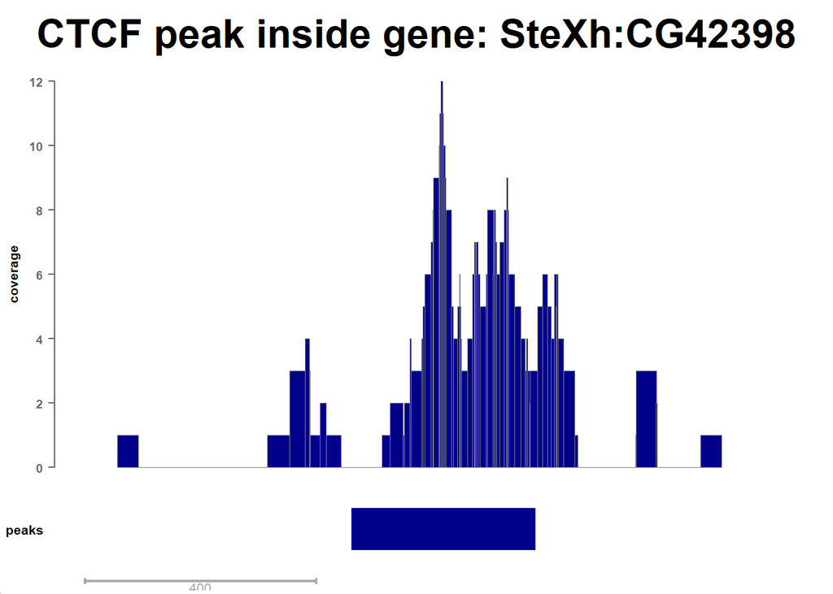

```r
plotSignalTracks(
  list(coverage = "aligned/ctcf.bam", peaks = peaks),
  region = peak_in_gene,
  extend = 500,
  main = paste("CTCF peak inside gene:", gene_name)
)
```

A peak overlapping the gene SteXh.CG42398 was selected using genomic overlap analysis, and the ChIP-seq signal was visualized around this intragenic peak.

# Extra

Checking how many peaks overlap the selected gene.

```r
hits_df <- data.frame(
  peak_idx = queryHits(hits),
  gene_idx = subjectHits(hits),
  gene_name = dr_genes$gene_name[subjectHits(hits)]
)

hits_df[hits_df$gene_name == gene_name, ]
```

```
##   peak_idx gene_idx     gene_name
## 1      182        8 SteXh:CG42398
```